# SOM LARVA en una matriz de 60 x 60 Neuronas

# 1. Loading raw data and getting it ready

```r
library(readr)
larva <- read_csv("~/GENER/SOMs/Ricardo/1. Raw Data/PSOMML_1Larva.csv")
larva <- larva[,-1:-2]
```

```r
library(readr)
larva <- read_csv("~/GENER/ricardo/1. Raw Data/PSOMML_1Larva.csv",
                          col_names = TRUE)
```

The dataframe obtained is made of `integer` values:

```r
str(larva)
```

```
Classes ‘tbl_df’, ‘tbl’ and 'data.frame':   262144 obs. of  3 variables:
 $ RED  : int  205 205 206 206 206 206 206 205 205 205 ...
 $ GREEN: int  209 209 210 210 210 210 210 209 209 209 ...
 $ BLUE : int  208 208 209 209 209 209 209 209 208 209 ...
```

This will be a problem down the line when feeding this data to the algorithm, values have to be changed to `numeric`:

```r
#larva[,'FILA'] <- as.numeric(as.factor(larva$FILA))
#larva[,'COLUMNA'] <- as.numeric(as.factor(larva$COLUMNA))
larva[,'RED'] <- as.numeric(as.factor(larva$RED))
larva[,'GREEN'] <- as.numeric(as.factor(larva$GREEN))
larva[,'BLUE'] <- as.numeric(as.factor(larva$BLUE))
```

Whit this taken care of we have a database ready to be fed to the algorithmL

```r
str(larva)
```

```
Classes ‘tbl_df’, ‘tbl’ and 'data.frame':   262144 obs. of  3 variables:
 $ RED  : num  162 162 163 163 163 163 163 162 162 162 ...
 $ GREEN: num  169 169 170 170 170 170 170 169 169 169 ...
 $ BLUE : num  171 171 172 172 172 172 172 172 171 172 ...
```

# 2 Initial exploration of data

A brief summary of the values of the variable can help with the initial understanding of things:

```r
summary(larva)
```

```
      RED            GREEN            BLUE
 Min.   :  1.0   Min.   :  1.0   Min.   :  1.0
 1st Qu.:158.0   1st Qu.:163.0   1st Qu.:167.0
 Median :159.0   Median :165.0   Median :168.0
 Mean   :157.8   Mean   :162.9   Mean   :165.3
 3rd Qu.:161.0   3rd Qu.:166.0   3rd Qu.:170.0
 Max.   :165.0   Max.   :171.0   Max.   :175.0
```

# 3 Self Organizing Map

## Loading required package

```r
require(kohonen)
```

## Changing dataframe to a `matrix`

```r
#I removed the function scale() because it does not need to be scaled.
larva.matrix <- as.matrix(larva)

#TEST
larva.matrixTest <- larva.matrix[1:20000,]
```

## Creating the SOM grid

```r
som_grid60x60 <- somgrid(xdim = 60, ydim = 60, topo = "rectangular")
```

## Training progress evaluation

```r
plot(som_model60, type = "changes")
```

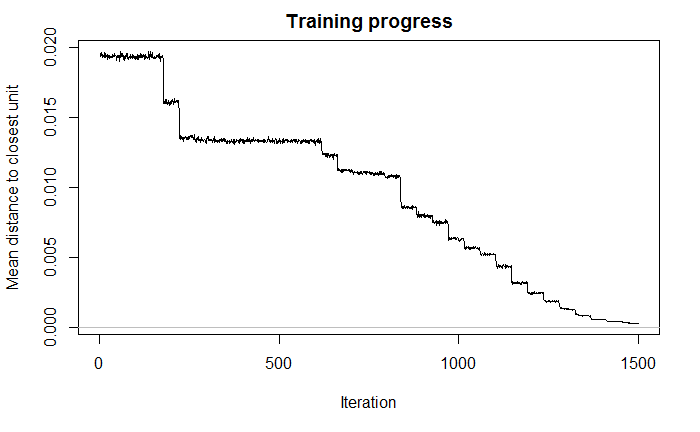